# Análisis espaciotemporal: fundamentos

Luis A. Cubillos

2024-12-11

# ¿Qué es un análisis espaciotemporal?

- Modelar componentes espaciales y temporales mediante el análisis de datos geolocalizados mediante modelos estadísticos.
- ¿Por qué analizar con modelos estadísticos y no modelos físicos o biológicos de los procesos involucrados?

# Metas del análisis espaciotemporal estadístico

1. Determinar un patrón en espacio y tiempo.
2. Inferencia de parámetros poblacionales.
3. Pronósticos en el tiempo.

# Componente espacial

- Primer principio de la Geografía (Tobler, 1970):

> “Todo está relacionado con todo lo demás, pero las cosas cercanas están más relacionadas que las cosas distantes.”
- Es la base para la **correlación espacial**.

# Correlación espacial

- La idea es que la cercanía física entre los puntos o elementos en el espacio tiende a generar una mayor similitud o interdependencia entre ellos, lo que se observa como una **dependencia espacial**.

# Conceptos para el patrón espacial

- **Dependencia espacial:** Proceso que determina que valores cercanos en el espacio pueden estar correlacionados a una cierta distancia (p.e., Indice de Moran)
- **Heterogeneidad espacial:** Procesos que ocurren en diferentes partes del espacio pueden tener diferentes comportamientos y patrones.

# Otros aspectos

- **Autocorrelación espacial:** correlación espacial de una variable consigo misma, positiva indica valores similares que tienden a agruparse, y negativa implica que valores diferentes se encuentran cercanos unos de otros.
- **Aleatoriedad espacial:** si los datos no muestran correlación espacial, el patrón espacial es estacionario.

# Autocorrelación espacial

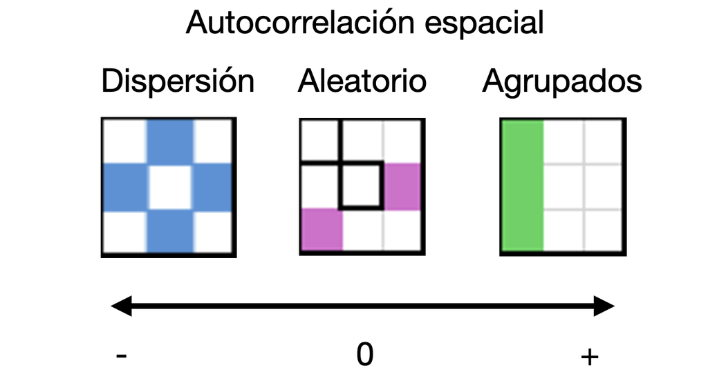

# Dependencia espacial vs. autocorrelación espacial

La dependencia espacial => implica variables exógenas a la variable de interés, i.e.,

$$y_j = \mu_y + f(\text{co-variables}_j) +
\epsilon_j$$

Autocorrelación espacial implica efectos endógenos de la variable de interés, i.e.,

$$y_j = \mu_y + \sum_i f(y_i - \mu_y) +
\epsilon_j$$
Contiene: error *espacialmente estructurado* y una fracción independiente (i.e., $\epsilon_j$).

# Correlación temporal

Se basa en la estructura de las series de tiempo, si una variable no es estacionaria implica que la media y la varianza cambia en el tiempo.

**Autocorrelación temporal:** En series de tiempo univariadas, valores cercanos en el tiempo son más similares entre sí que valores lejanos en el tiempo.

# Modelos estadísticos jerárquicos

- Incluyen un modelo para los datos, un modelo de los procesos, y un modelo para los parámetros.
- Análogo a los modelos en el espacio de los estados de series de tiempo.

# La estructura jerárquica

- Si los parámetros son tratados con distribución *prior* en la más baja jerarquía entonces se tiene un modelo Bayesiano jerárquico.
1. Modelo de los datos: $[\text{datos}|\text{procesos}, \text{parámetros}]$
2. Modelo de los procesos: $[\text{procesos}|\text{parámetros}]$
3. Parámetros del modelo: $[\text{parámetros}]$

# Probabilidad condicional

$$[\text{proceso},
\text{parms}|\text{datos}] \propto [\text{datos}|\text{procesos,parms}]
\times [\text{procesos}|\text{parms}] \times [\text{parms}]$$

Al dividir el lado derecho por $[\text{datos}]$, se debe aplicar la regla de probabilidad condicional de Bayes.

Modelos complejos requieren evaluación numérica del posterior, p.e. metodos MCMC.

# Modelos estadísticos espacio-temporales jerárquicos

Dos paradigmas:

$$[\text{observaciones}] =
[\text{verdadero proceso}] + [\text{error de observación}]$$

$$[\text{verdadero proceso}] =
[\text{regresión}] + [\text{proceso aleatorio dependiente}]$$

El segundo enfoque es un enfoque dinámico, mientras que el primero es un enfoque descriptivo.

# ¿Qué es INLA?

- Integrated Nested Laplace Approximation
- Introducido por Rue (2009), donde la estimación del Posterior utiliza aaproximación numérica.
- Marco conceptual unificado para analizar modelos latentes Gausianos.
- Exactitud y computacionalmente superior a métodos MCMC
- Disponible utilizando la interface [R-INLA Project](https://www.r-inla.org/home)

# Tutoriales

[Gómez-Rubio, Virgilio (2020). Bayesian Inference with INLA. Chapman & Hall/CRC Press. Boca Raton, FL.](https://becarioprecario.bitbucket.io/inla-gitbook/index.html)

[Moraga, Paula (2023). Spatial Statistics for Data Science: Theory and Practice with R](https://www.paulamoraga.com/book-spatial/)

Otros disponibles en:

[R-INLA Proyect - Books](https://www.r-inla.org/learnmore/books)

# Modelos latentes Gausiano

$$\eta_i =
g(\mu_i)=\alpha+\sum_{j=1}^{n_{\beta}}\beta_jz_{ji}+\sum_{k=1}^{n_f}f_k(c_{ki})+\epsilon_i$$
donde: $g(.)$ es la función de enlace, y

$\alpha$ : intercepto $\beta$ : efectos lineales de las covariables $z_j$ $f_k(.)$ : efectos no-lineales de las covariables $c_k$ $\epsilon$ : efectos aleatorios $iid$

# Modelos latentes Gausiano (cont.)

- Consider todos los parámetros (variables aleatorias) del predictor lineal en un campo latente, i.e.,

$$\mathbf{x} = [ \alpha, \beta,
f_k(.),\eta]$$

- Un modelo latente Gausiano se obtiene asignando prior Gausiano a todos los elementos de $\mathbf{x}$
- Flexible debido a las muchas formas diferentes de las funciones desconocidas $f_k(.)$ (incluye covariables temporales y/o espaciales)
- Los *hiperparámetros* dan cuenta de la variablidad y grado de dependencia.

# Ejemplos de modelos latentes Gausianos

- GLMM y GAMM
- Regresión semiparamétrica
- Análisis de sobrevivencia
- Log-Gaussian Cox-processes (útil para muestreo preferencial)
- Modelos geoestadísticos
- **Modelos espaciales y espaciotemporales**
- Modelos lineal dinámicos
- Modelos en el espacio de los estados

# Modelo espaciotemporal

1. Ocurrencia:

$$Z_{s,t} \sim
\text{Ber}(\pi_{s,t})$$

$\pi_{s,t}$ es la occurrence.

$s_i$ son localidades (lances), donde $i = 1, 2, ..., n$.

$t_j$ indica tiempo, donde $j = 1, 2, ..., t$.

# Predictor lineal para la ocurrencia

$$\text{logit}(\pi_{s,t})=\alpha_z + f(D)
+ f(T) + V_{s,t}^z$$
$\alpha_z$: intercepto.

$f(D)$ : efectos no-lineal aleatorio de la profundidad de fondo.

$f(T)$ : efectos temporal aleatorio no estructurado ($iid$).

$V_{s,t}=w_{s,t}$ : campo geoestadístico con función de covarianza dada por el rango y la desviación estándard marginal del campo espacial ($w_{s,t}$).

# Campo espacial

$$\mathbf{W} \sim \text{N}(0,
Q(\kappa,\tau))$$

$\mathbf{Q}$ es una “sparse precision matrix”, defined por “Stochastic Partial Differential Equations (SPDE)” para representar una aproximación del campo Gausiano continuo (GF) a través de un “Gaussian Markov Random Field (GMRF)”.

# Stochastic Partial Differential Equations

- La aproximación SPDE (Lindgren et al., 2011) contiene los parámetros $\kappa$ y $\tau$ del campo espacial, i.e.,

$$w_{s}=(\kappa-\Delta)^{\alpha/2}\tau
X(s)$$

$\kappa>0$ es el parámetro de escala

$\tau$ controla la varianza del campo Gausiano

$X(s)$ es el campo Gaussian aleatorio

$w_s$ is ruido estacionario.

# Correlación espacial de Matern

$$\rho_s(X_s)=\frac{2^{1-\nu}}{\Gamma(\nu)}(\kappa
\parallel s_i - s_j\parallel)^{\nu}K_{\nu}(\kappa \parallel s_i -
s_j\parallel)$$

- Los parámetros relacionados al rango y escala de la estructura de covarianza Mátern, $\kappa>0$ y parámetro ($\nu>0$),

$\parallel s_i - s_j \parallel$ denota distancia Euclidean, y $K_{\nu}$ is la función de Bessel de segundo orden modificada.

El modelo SPDE es una function de una trama y un parámetro $\alpha$ del campo espacial.

# Modelo espaciotemporal densidad

2. Hurdle o Delta-Gamma: CPUA condicional a la presencia, i.e.,

$$Y_{s,t} = \left\{\begin{matrix}
0 & \text{if} \: Z_{s,t} = 0 \\
\text{Gamma}(\mu_{s,t},c \phi) & \text{if} \: Z_{s,t} = 1
\end{matrix}\right.$$

$\text{E}(Y)=\mu$

$\text{Var}(Y)=\mu^2/(c \phi)$

$c$ es un parámetro de escalay $1/ \phi$ es un parámetro de dispersión.

**Nota:** INLA considera precision como (1/variance), y para Gamma es equivalente a $\phi$.

# Predictor lineal

$$\log (\mu_{s,t})= \alpha_y + f_1(D) +
f_2(T) + V_{s,t}^y$$

# Efectos no-lineales

Los efectos aleatorios no-lineales ($f(.)$), pueden ser modelados como:

- Modelos “iid”
- Modelos con caminanta aleatoria simple RW1 o doble RW2
- Modelos con autocorrelación AR(1)

Las variables aleatorias continuas como la profundidad pueden ser divididas en clases o grupos.

# Modelos estucturales para el campo espacial

Campo espacial constante: $V_{s,t} = W_{s}$

Campo espacial oportunista (replicas independientes en el tiempo): $V_{s,t} = W_{s,t}$

Campo espacial progresivo (con autocorrelación temporal): $V_{s,t} = W_{s,t} + \sum_{k=1}^K \rho_kV_{s(t-k)}$

# Selección de modelos

- DIC
- WAIC

# Grilla de predicción

INLA utiliza ajustes para la estimación diferente de la predicción.

- Grilla de predicción: necesaria para la predicción de las variables de interés y la obtención de índices de abundancia.

# Indice de biomasa

$$\hat{I}_{t} =
\sum_{j=1}^{n_j}a_j\hat{y}_{j,t}$$
$\hat{I}_{t}$ biomasa integrada en el año $t$

$a_{j}$ superficie de cada celda de la grilla (km$^2$)

# Estimación del modelo

$$\hat{y}_{j,t} = \exp(\hat{Y}_{j,t})
\times \exp(\hat{Z}_{j,t})/(1+\exp(\hat{Z}_{j,t}))$$

$\hat{Y}_{j,t}$ es la estimación Gamma,

$\hat{Z}_{j,t}$ is la ocurrencia.

# PAUSA

CAFE